# Introduction to R Markdown

BDSI 2024; University of Michigan

## About me

- Associate Professor in Biostatistics
- Former PhD student at Michigan Biostatistics
- R user and aficionado

[video not shown]

## The basics

## When to use

- Reports
- Slides
- Manuscripts / books
- Simple websites

## Why to use

- R code and interpretations integrated into a single document
- Separates task of *reporting* the results from *formatting* the results:
  - decreases risk of copy-paste errors
  - decreases workload
- Quickly create the same document in different formats, e.g. slides to show and handouts for the audience

[figure not shown]

source: [rstudio.com](https://rmarkdown.rstudio.com/lesson-2.html)

[figure not shown]

whatever format you want to create: html, pdf, docx, …

image source: [rstudio.com](https://rmarkdown.rstudio.com/lesson-2.html)

[figure not shown]

`pandoc`: “an open-source document converter” ([wikipedia](https://en.wikipedia.org/wiki/Pandoc)). Translates markup from one type of format, e.g. markdown, to another

image source: [rstudio.com](https://rmarkdown.rstudio.com/lesson-2.html)

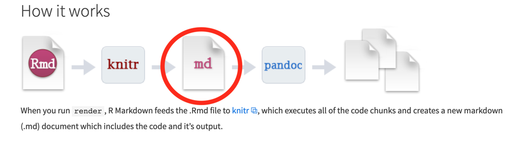

`md`: a document written in markdown, “a lightweight markup language with plain text formatting syntax” ([wikipedia](https://en.wikipedia.org/wiki/Markdown)). Github also uses markdown.

image source: [rstudio.com](https://rmarkdown.rstudio.com/lesson-2.html)

[figure not shown]

`knitr`: an [R package](https://yihui.name/knitr/) for creating reports directly in R. Will translate your R markdown document (Rmd), including embedded R code, to a plain markdown document

image source: [rstudio.com](https://rmarkdown.rstudio.com/lesson-2.html)

[figure not shown]

Rmd: file type recognized by RStudio. This is where everything goes: your header, R code chunks, and your content written in markdown

image source: [rstudio.com](https://rmarkdown.rstudio.com/lesson-2.html)

From RStudio, go to `File` > `New File` > `R Markdown...`

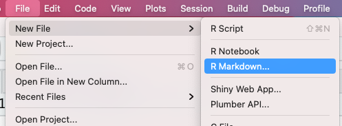

## Choose your document type

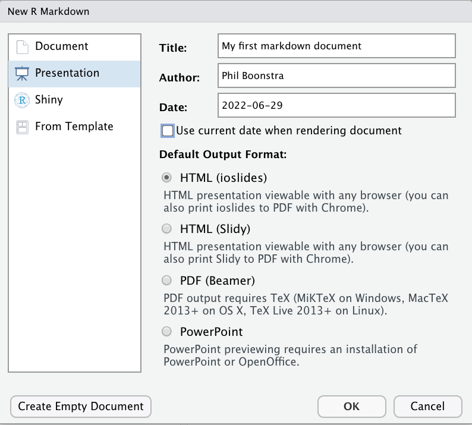

## Get a template

[figure not shown]

## “YAML” Header

[figure not shown]

## Write R code in chunks

[figure not shown]

## Write plain text

[figure not shown]

## Knit your document to see the final product

[figure not shown]

## Knit your document to see the final product

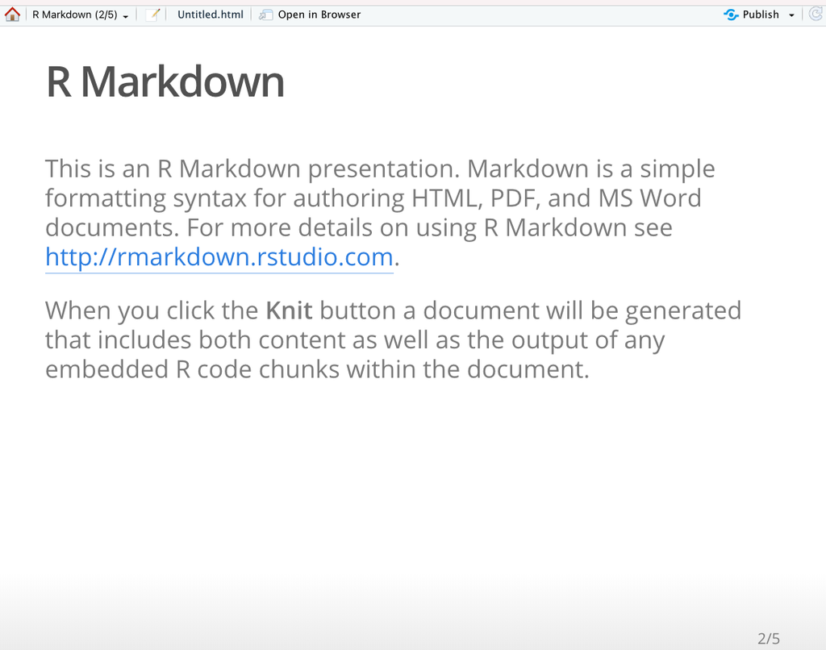

[figure not shown]

This is what my code chunk looks like for the previous slide:

````r
```{r, out.width = paste0(image_scaler*400,"px"), echo = F}
include_graphics("images/knit_menu.png")
```
````

## Try it out: Option 1

1. Download R (https://cran.r-project.org/)
2. Download RStudio to interface with R (https://posit.co/)
3. Go to https://github.com/psboonstra/markdown-workshop, then ‘Code’, then ‘Download ZIP’

[figure not shown]

1. Unzip the folder, then open the `.RProj` file
2. In RStudio, click on ‘Files’ at the bottom, and pull up `01-exercise.Rmd`

## Try it out: Option 2

1. Go to https://posit.cloud/ > Get Started
2. Create an account
3. Click the dropdown menu *next to* the New Project button, select ‘New Project from Git Repository’, and enter this URL: https://github.com/psboonstra/markdown-workshop
4. Click on ‘Files’ at the bottom, and pull up `01-exercise.Rmd`

## Your turn

Complete the tasks in `01-exercise.Rmd`.

`08:00`

## Takeaways

- Markdown tries to focus on simplicity
- Chunk options control how the chunk is evaluated and used
- You can knit the same document to different formats (sometimes easy to do, sometimes requires a bit of finagling)
- Consider using in-line chunks instead of hard-coding results

## Use Markdown to tell your story

## Early code chunk

If you name a variable in an earlier code chunk, you can refer to it again in a later chunk.

```r
x <- rnorm(20)
y <- 3 * x + rnorm(length(x))
my_data = tibble(x = x, y = y)
```

## Later code chunk

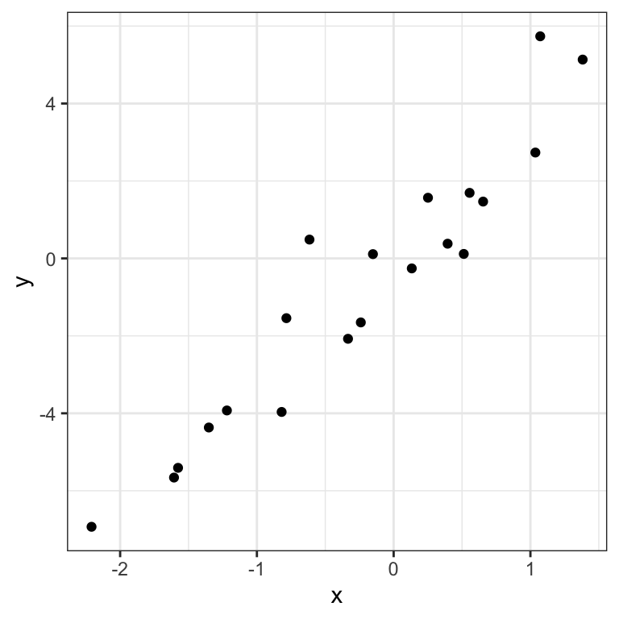

```r
library(ggplot2)
ggplot(data = my_data) +
  geom_point(aes(x, y))
```

## Tables

```r
my_data
```

```
## # A tibble: 20 × 2
##         x      y
##     <dbl>  <dbl>
##  1 -1.61  -5.66
##  2  0.513  0.116
##  3 -1.22  -3.93
##  4  0.133 -0.258
##  5 -2.21  -6.93
##  6  0.251  1.57
##  7 -0.615  0.486
##  8  0.395  0.380
##  9  1.07   5.74
## 10 -1.58  -5.41
## 11  1.38   5.13
## 12  0.654  1.47
## 13 -1.35  -4.37
## 14 -0.240 -1.65
## 15 -0.784 -1.54
## 16 -0.151  0.111
## 17 -0.819 -3.96
## 18  0.555  1.69
## 19 -0.334 -2.08
## 20  1.04   2.73
```

## Tables using ‘kable’

```r
kable(my_data)
```

| x | y |
| --- | --- |
| -1.60610 | -5.65920 |
| 0.51276 | 0.11607 |
| -1.21935 | -3.92632 |
| 0.13253 | -0.25784 |
| -2.20918 | -6.93057 |
| 0.25106 | 1.56682 |
| -0.61545 | 0.48648 |
| 0.39463 | 0.38005 |
| 1.07182 | 5.73586 |
| -1.57653 | -5.40811 |
| 1.38210 | 5.13500 |
| 0.65412 | 1.46784 |
| -1.35147 | -4.36656 |
| -0.24011 | -1.65272 |
| -0.78437 | -1.54286 |
| -0.15146 | 0.11104 |
| -0.81912 | -3.96463 |
| 0.55536 | 1.69327 |
| -0.33370 | -2.07557 |
| 1.03632 | 2.73430 |

## Random lessons I’ve learned

## Markdown can be really, really finicky about horizontal and vertical spacing

If something (a new header option, a code chunk, etc) is not working as you expect, try adding an additional linebreak

If experimenting with a new feature, re-knit frequently

## Caching

If, like me, you become a compulsive re-knitter, the code chunk option `cache = TRUE` is both useful and dangerous.

````markdown
```{r, cache = TRUE}
# some intensive task
```
````

As long as you don’t change *anything* in the chunk, you won’t need to re-run the intensive task upon re-knitting. However, things can go awry…

- Open the file `caching_mishap.Rmd` and make sure you understand the intended behavior (should be trivial!)
- Knit the document
- Now edit your first chunk, changing to `x <- rnorm(n = 1, mean = 0)` and leaving the second chunk alone
- Re-knit your document

That’s how we get results like this:

```r
x <- rnorm(n = 1, mean = 0)
```

```r
x
```

```
## [1] 100.71
```

### What happened

We invalidated the cache in the first chunk (triggering it to run again) without invalidating the cache in the second chunk (so it was left alone)

### Possible solutions

- Consider if the chunks should be combined
- You can invalidate a cache by adding a comment character (`#`) at the end of a line, or making some other innocuous change to your chunk. Even extra white space will invalidate the cache
- Go to `Knit` > `Clear Knitr Cache...` or delete directly the folder ending in `[filename]_cache` in your working directory

> [#RMarkdown](https://twitter.com/hashtag/RMarkdown?src=hash&ref_src=twsrc%5Etfw) question: If I cache the chunk that loads the R packages, then I sometimes (not always) get random errors from downstream chunks that can't find a loaded function, as if it wasn't loaded. Un-cache-ing the chunk seems to fix the problem. Anyone else encounter this?

> — Philip Boonstra ((**psboonstra?**)) [February 9, 2021](https://twitter.com/psboonstra/status/1359145618854338567?ref_src=twsrc%5Etfw)

> The cache mechanism is not to be used with code chunk that have side effect used by other chunks - loading package that are used by other chunk is one of this. See more in :https://t.co/bpKPzkFMad  
> If you activate cache globally you need to se cache=FALSE

> — Christophe Dervieux ((**chrisderv?**)) [February 10, 2021](https://twitter.com/chrisderv/status/1359516129560064001?ref_src=twsrc%5Etfw)

> The most appropriate use case of caching is to save and reload R objects that take too long to compute in a code chunk, and the code does not have any side effects, such as changing global R options via options() (such changes will not be cached). If a code chunk has side effects, we recommend that you do not cache it.

[Section 11.4, RMarkdown Cookbook](https://bookdown.org/yihui/rmarkdown-cookbook/cache.html)

## `knitr` can run code in other languages

Including

- Python
- SQL
- Julia
- Stan
- Javascript

Use `` ```{python} `` to start a python code chunk, `` ```{julia} `` to start a julia code chunk, `` ```{bash} `` to start a Shell script, etc.

You may need external language engines to successfully call other languages. I have not used this functionality before.

see [Chapter 2.7, R Markdown: The Definitive Guide](https://bookdown.org/yihui/rmarkdown/language-engines.html)

## More practice

## You can knit R scripts!

You are not limited to using Markdown in Rmd files – you can knit R scripts using the same shortcut: *Cmd+Shift+K* / *Ctrl+Shift+K*

- Use `#'` to indicate a switch to markdown
- Use `#+` to start a new chunk

## Your turn again

Open `02-exercise.R` and complete the tasks.

`08:00`

## Embedding html tags into your markdown

```
<iframe src="https://isitchristmas.com/"></iframe>
```

yields

[interactive chart not shown]

## Data analyses in R

## `readr` package

Part of the `tidyverse` (along with `dplyr` and `ggplot2`):

[figure not shown]

https://www.tidyverse.org/

`readr` gives you tools to read in data from files outside R, wrangled and manipulated, and then written to files outside R:

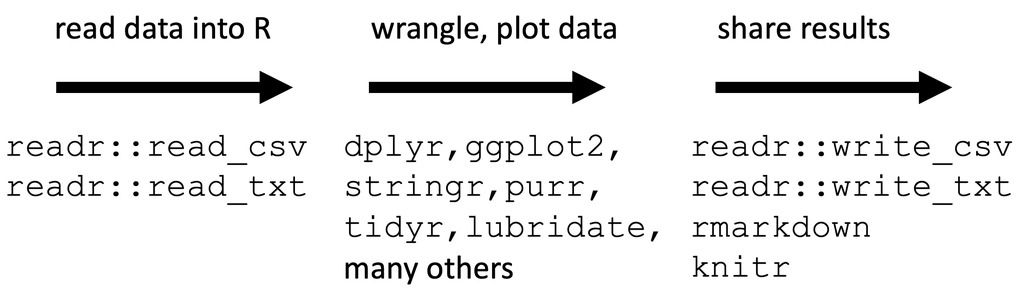

The workhorse of the `readr` package is `read_csv`, which reads a comma-separated value (`csv`) file into R as a `data.frame` From the help page:

```
read_csv(file, col_names = TRUE, col_types = NULL, locale = default_locale(),
na = c("", "NA"), quoted_na = TRUE, quote = "\"", comment = "", trim_ws = TRUE,
skip = 0, n_max = Inf, guess_max = min(1000, n_max), progress = show_progress(),
skip_empty_rows = TRUE)
```

Typical use is `my_data <- read_csv("my_files_path.csv")`

## Digression: How does `read_csv` know where to look?

Get your current working directory in R:

```r
getwd()
```

```
## [1] "/Users/philb/Desktop/Work/BDSI2023+/markdown-workshop"
```

How did R know this was my desired working directory? Why did I not need to do this:

```r
setwd("/Users/philb/Desktop/Work/BDSI2023/markdown-workshop")
```

## R Projects and working directories

Your working directory is automatically set when you work inside an R project.

[figure not shown]

To *create* an R project, go to `File` > `New Project...` > `Existing Directory` and choose your folder

To *open* an existing R project, find the `.Rproj` file or go to `File` > `Open Project...`

## Mouse xenograft study

Varna, Bertheau, and Legrès (2014)

```r
(tumor_growth <- read_csv("tumor_growth.csv"))
```

```
## # A tibble: 574 × 5
##    Grp   Group    ID   Day   Size
##    <chr> <dbl> <dbl> <dbl>  <dbl>
##  1 1.CTR     1   101     0   41.8
##  2 1.CTR     1   101     3   85
##  3 1.CTR     1   101     4  114
##  4 1.CTR     1   101     5  162.
##  5 1.CTR     1   101     6  178.
##  6 1.CTR     1   101     7  325
##  7 1.CTR     1   101    10  624.
##  8 1.CTR     1   101    11  648.
##  9 1.CTR     1   101    12  836.
## 10 1.CTR     1   101    13 1030.
## # ℹ 564 more rows
```

## One more time

Open `03-exercise.Rmd` and complete the tasks.

`15:00`

## What to do next

[interactive chart not shown]

https://rmarkdown.rstudio.com/

[R Markdown on RStudio.com](https://rmarkdown.rstudio.com/index.html)

[R Markdown: The definitive guide](https://bookdown.org/yihui/rmarkdown/)

- Free, online version of a book written by the RStudio experts

[R Markdown cheatsheet](https://raw.githubusercontent.com/rstudio/cheatsheets/master/rmarkdown-2.0.pdf)

- Helpful quick reference

[Mastering markdown](https://guides.github.com/features/mastering-markdown/)

- Reference site for markdown langauge

[Project-oriented workflow](https://www.tidyverse.org/blog/2017/12/workflow-vs-script/)

- The benefits of working in self-contained projects

## References

Varna, Mariana, Philippe Bertheau, and Luc G Legrès. 2014. “Tumor Microenvironment in Human Tumor Xenografted Mouse Models.” *Journal of Analytical Oncology* 3 (3): 159–66.